# The deconvolution analysis in pancreas islet tissues

Weixu Wang

2022/1/24

```r
##load packages
suppressPackageStartupMessages(library(Biobase))
suppressPackageStartupMessages(library(SingleCellExperiment))
suppressPackageStartupMessages(library(ggplot2))
suppressPackageStartupMessages(library(cowplot))
suppressPackageStartupMessages(library(WGCNA))
suppressPackageStartupMessages(library(scater))
suppressPackageStartupMessages(library(GSVA))
suppressPackageStartupMessages(library(pheatmap))
suppressPackageStartupMessages(library(clusterProfiler))
suppressPackageStartupMessages(library(org.Hs.eg.db))
suppressPackageStartupMessages(library(nnls))
source("/mnt/data1/weixu/HiDe/revised/ENIGMA.R")
```

Loading the datasets we need, the datasets could be downloaded from Github https://github.com/WWXkenmo/ENIGMA/tree/main/ENIGMA_analysis

```r
baron <- readRDS("/mnt/data1/weixu/HiDe/pancreas/baron_processed.rds")
SASP <- readRDS("/mnt/data1/weixu/HiDe/revised/reproduce_pancreas/SASP.rds")
CellAge <- readRDS("/mnt/data1/weixu/HiDe/revised/reproduce_pancreas/CellAge.rds")
pancreas_bulk <- read.table("/mnt/data1/weixu/HiDe/pancreas/pancreas/bulk/Fadista/GSE50244_Genes_counts_TMM_NormLength_atLeastMAF5_expressed.txt",sep="\t",stringsAsFactors=FALSE,header=TRUE,row.names=1)
```

Our single cell datasets of normal pancreas islet tissue (reference) is downloaded from https://hemberg-lab.github.io/scRNA.seq.datasets/human/pancreas/. We generated the reference profile matrix through S-mode correction.

```r
pancreas_bulk_set <- ExpressionSet(as.matrix(pancreas_bulk))
baron$cell_type1 <- as.character(as.matrix(baron$cell_type1))
tmp_pancreas = remove_batch_effect(pancreas_bulk_set,baron,"cell_type1",n=1000)
```

```
## Tue Jan 25 00:27:27 2022 generating pseudo bulk...
## Tue Jan 25 00:31:40 2022 do ComBat...
## Found 1022 genes with uniform expression within a single batch (all zeros); these will not be adjusted for batch.
```

```
## Found2batches
```

```
## Adjusting for0covariate(s) or covariate level(s)
```

```
## Standardizing Data across genes
```

```
## Fitting L/S model and finding priors
```

```
## Finding parametric adjustments
```

```
## Adjusting the Data
```

```
## Tue Jan 25 00:31:49 2022 restore reference...
```

```r
###The batch-correct profile matrix would be stochastic because of random sampling, one could use our saved files to reproduce the results in paper.
tmp_pancreas <- readRDS("/mnt/data1/weixu/HiDe/revised/reproduce_pancreas/tmp_pancreas.rds")
```

Calculate the cell type fraction matrix

```r
Fra_pancreas <- get_proportion(tmp_pancreas$bulk,tmp_pancreas$cell_type1)
```

```
## Tue Jan 25 00:31:56 2022 Calculating cell type proportion of bulk samples...
```

Running the ENIGMA with default parameter setting

```r
egm_model1 <- cell_deconvolve(X=as.matrix(log2((tmp_pancreas$bulk)+1)),
                                     theta=Fra_pancreas$theta,
                                     R=as.matrix(log2(tmp_pancreas$cell_type1+1)),
                                     epsilon = 0.001,
                                     alpha=0.5,    beta=0.1,tao_k=0.01,max.iter=1000,verbose=FALSE,Normalize=FALSE,pre.process="log")
```

```
## Done!
## Converge in 18 steps
```

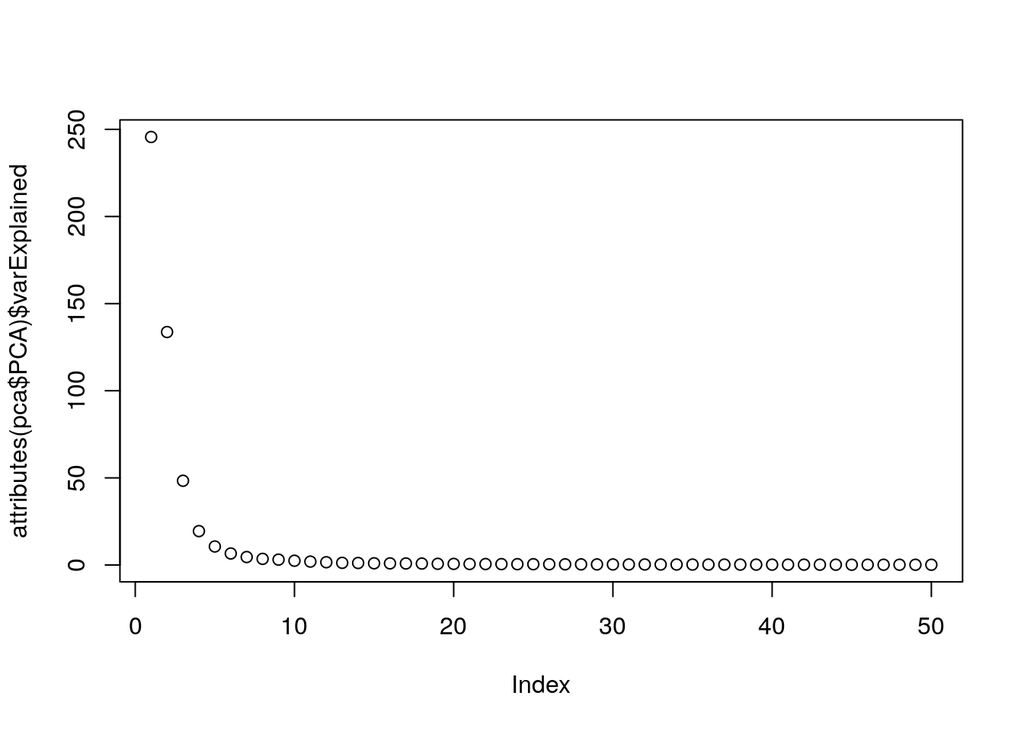

```r
# visualize the CSE profiles through t-SNE
pancreas <- cell_type_pancreas <- NULL
for(i in 1:ncol(tmp_pancreas$cell_type1)){
 pancreas <- cbind(pancreas,egm_model1$X_k[,Fra_pancreas$theta[,i]!=0,i])
 cell_type_pancreas <- c(cell_type_pancreas,rep(colnames(tmp_pancreas$cell_type1)[i],sum(Fra_pancreas$theta[,i]!=0)))
}

sce_pancreas <- SingleCellExperiment(assays = list(logcounts = pancreas))
sce_pancreas$cell_type <- cell_type_pancreas
sce_pancreas <- runPCA(sce_pancreas,scale=TRUE)
pca <- reducedDims(sce_pancreas)
plot(attributes(pca$PCA)$varExplained)
```

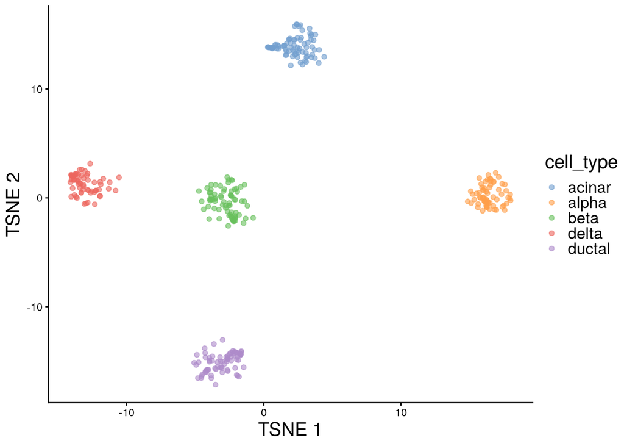

```r
sce_pancreas <- runTSNE(sce_pancreas)

plotTSNE(sce_pancreas, colour_by="cell_type") +theme(text = element_text(size=15))
```

## Calculating the correlation between each cell senescence score and BMI, HbA1c

load the metadata information of bulk, which contains the level of HbA1c

```r
metadata <- read.csv("/mnt/data1/weixu/HiDe/pancreas/metadata_pancreas.csv",stringsAsFactors = FALSE,row.names=1)
rownames(metadata) <- paste0("X",rownames(metadata),sep="")
sample <- intersect(rownames(metadata),rownames(Fra_pancreas$theta))

###clinically define the T2D patients as HbA1c > 6.5
label <- rep(0, nrow(metadata));label[metadata$HbA1c >= 6.5] <- 1
pt_ct <- c("Acinar cell","Alpha cell","Beta cell","Delta cell","Ductal cell")
```

Using GSVA to evaluate each sample senescence score, and using the scatter plot to visualize the correlation between senescence of each cell type and BMI.

```r
bmi_tab <- NULL
for(ct in c(1:5)){
PS_gene <- intersect(rownames(tmp_pancreas$cell_type1),c(SASP$Gene,CellAge$gene_symbol));PS_gene <- PS_gene[rowMeans(log2(as.matrix(pancreas_bulk)+1)[PS_gene,])>0.1]
scrna <- egm_model1$X_k[,,ct]
es.dif <- gsva(scrna, list(PS_gene), mx.diff=TRUE, verbose=FALSE, parallel.sz=1)
s = es.dif[1,]
names(s) <- colnames(egm_model1$X_k)

color <- label
color[label==1] <- rgb(254,118,109,maxColorValue = 255)
color[label==0] <- rgb(118,167,0,maxColorValue = 255)
scatter_dat <- data.frame(BMI=metadata[sample,]$BMI,Sene.Score=s[sample],label=label,color=color)
scatter_dat$label[scatter_dat$label==1] <- "T2D"
scatter_dat$label[scatter_dat$label==0] <- "Normal"
scatter_dat$label <- as.factor(scatter_dat$label)
scatter_dat_filter <- scatter_dat[Fra_pancreas$theta[sample,ct]!=0,]
print(cor(scatter_dat_filter[,1],scatter_dat_filter[,2],method="p"))
print(cor.test(scatter_dat_filter[,1],scatter_dat_filter[,2],method="p")$p.value)
bmi_tab <- rbind(bmi_tab,c(cor(scatter_dat_filter[,1],scatter_dat_filter[,2],method="p"),cor.test(scatter_dat_filter[,1],scatter_dat_filter[,2],method="p")$p.value))
eval(parse(text = paste("p_bmi_",ct," <- ggplot(scatter_dat_filter, aes(x=BMI, y=Sene.Score, color=label)) + scale_color_manual(values=c(rgb(118,167,0,maxColorValue = 255),rgb(254,118,109,maxColorValue = 255)))+
    geom_point()+theme_classic()+theme(text = element_text(size=12))+geom_smooth(method=lm, se=FALSE, fullrange=TRUE,col='black')",sep="")))
value1 <- round(cor(scatter_dat_filter[,1],scatter_dat_filter[,2],method="p"),3)
value2 <- round(cor.test(scatter_dat_filter[,1],scatter_dat_filter[,2],method="p")$p.value,3)
eval(parse(text = paste("p_bmi_",ct," <-","p_bmi_",ct,"+labs(y='Senescence Score',title='",pt_ct[ct],": R = ",value1, "; P-value = ",value2, "')",sep="")))
}
```

```
##             [,1]
## [1,] -0.04400143
## [1] 0.7236682
##          [,1]
## [1,] 0.290366
## [1] 0.02844509
##           [,1]
## [1,] 0.3335884
## [1] 0.004771501
##           [,1]
## [1,] 0.1441345
## [1] 0.2803876
##           [,1]
## [1,] 0.1248884
## [1] 0.317731
```

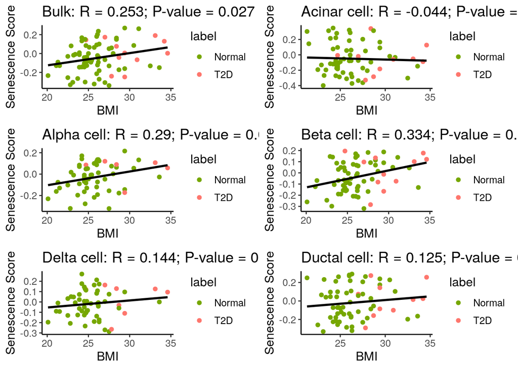

```r
scrna <- log2(as.matrix(pancreas_bulk)+1)
es.dif <- gsva(scrna, list(PS_gene), mx.diff=TRUE, verbose=FALSE, parallel.sz=1)
s = es.dif[1,]
names(s) <- colnames(egm_model1$X_k)

color <- label
color[label==1] <- rgb(254,118,109,maxColorValue = 255)
color[label==0] <- rgb(118,167,0,maxColorValue = 255)
scatter_dat <- data.frame(BMI=metadata[sample,]$BMI,Sene.Score=s[sample],label=label,color=color)
scatter_dat$label[scatter_dat$label==1] <- "T2D"
scatter_dat$label[scatter_dat$label==0] <- "Normal"
scatter_dat$label <- as.factor(scatter_dat$label)
scatter_dat_filter <- scatter_dat
bmi_tab <- rbind(bmi_tab,c(cor(scatter_dat_filter[,1],scatter_dat_filter[,2],method="p"),cor.test(scatter_dat_filter[,1],scatter_dat_filter[,2],method="p")$p.value))
eval(parse(text = paste("p_bmi_bulk"," <- ggplot(scatter_dat_filter, aes(x=BMI, y=Sene.Score, color=label)) + scale_color_manual(values=c(rgb(118,167,0,maxColorValue = 255),rgb(254,118,109,maxColorValue = 255)))+
    geom_point()+theme_classic()+theme(text = element_text(size=12))+geom_smooth(method=lm, se=FALSE, fullrange=TRUE,col='black')",sep="")))
value1 <- round(cor(scatter_dat_filter[,1],scatter_dat_filter[,2],method="p"),3)
value2 <- round(cor.test(scatter_dat_filter[,1],scatter_dat_filter[,2],method="p")$p.value,3)
eval(parse(text = paste("p_bmi_bulk","<- p_bmi_bulk","+labs(y='Senescence Score',title='Bulk: R = ",value1, "; P-value = ",value2, "')",sep="")))

plot_grid(p_bmi_bulk,p_bmi_1,p_bmi_2,p_bmi_3,p_bmi_4,p_bmi_5,nrow=3,ncol=2)
```

Using GSVA to evaluate each sample senescence score, and using the scatter plot to visualize the correlation between senescence of each cell type and HbA1c.

```r
hba1c_tab <- NULL
for(ct in c(1:5)){
PS_gene <- intersect(rownames(tmp_pancreas$cell_type1),c((SASP$Gene),(CellAge$gene_symbol)));PS_gene <- PS_gene[rowMeans(log2(as.matrix(pancreas_bulk)+1)[PS_gene,])>0.1]
scrna <- egm_model1$X_k[,,ct]
es.dif <- gsva(scrna, list(PS_gene),mx.diff=TRUE, verbose=FALSE, parallel.sz=1)
s = es.dif[1,]
names(s) <- colnames(egm_model1$X_k)

color <- label
color[label==1] <- rgb(254,118,109,maxColorValue = 255)
color[label==0] <- rgb(118,167,0,maxColorValue = 255)
scatter_dat <- data.frame(HbA1c=metadata[sample,]$HbA1c,Sene.Score=s[sample],label=label,color=color)
scatter_dat$label[scatter_dat$label==1] <- "T2D"
scatter_dat$label[scatter_dat$label==0] <- "Normal"
scatter_dat$label <- as.factor(scatter_dat$label)
scatter_dat_filter <- scatter_dat[Fra_pancreas$theta[sample,ct]!=0,]
print(cor(scatter_dat_filter[,1],scatter_dat_filter[,2],method="p"))
print(cor.test(scatter_dat_filter[,1],scatter_dat_filter[,2],method="p")$p.value)
hba1c_tab <- rbind(hba1c_tab,c(cor(scatter_dat_filter[,1],scatter_dat_filter[,2],method="p"),cor.test(scatter_dat_filter[,1],scatter_dat_filter[,2],method="p")$p.value))
eval(parse(text = paste("p_hba1c_",ct," <- ggplot(scatter_dat_filter, aes(x=HbA1c, y=Sene.Score, color=label)) + scale_color_manual(values=c(rgb(118,167,0,maxColorValue = 255),rgb(254,118,109,maxColorValue = 255)))+
    geom_point()+theme_classic()+theme(text = element_text(size=12))+geom_smooth(method=lm, se=FALSE, fullrange=TRUE,col='black')",sep="")))
value1 <- round(cor(scatter_dat_filter[,1],scatter_dat_filter[,2],method="p"),3)
value2 <- round(cor.test(scatter_dat_filter[,1],scatter_dat_filter[,2],method="p")$p.value,3)
eval(parse(text = paste("p_hba1c_",ct," <-","p_hba1c_",ct,"+labs(y='Senescence Score',title='",pt_ct[ct],": R = ",value1, "; P-value = ",value2, "')",sep="")))
}
```

```
##             [,1]
## [1,] 0.006128246
## [1] 0.9607453
##          [,1]
## [1,] 0.252327
## [1] 0.05827968
##           [,1]
## [1,] 0.2621056
## [1] 0.02838504
##           [,1]
## [1,] 0.2292107
## [1] 0.08349791
##            [,1]
## [1,] 0.06255234
## [1] 0.6178096
```

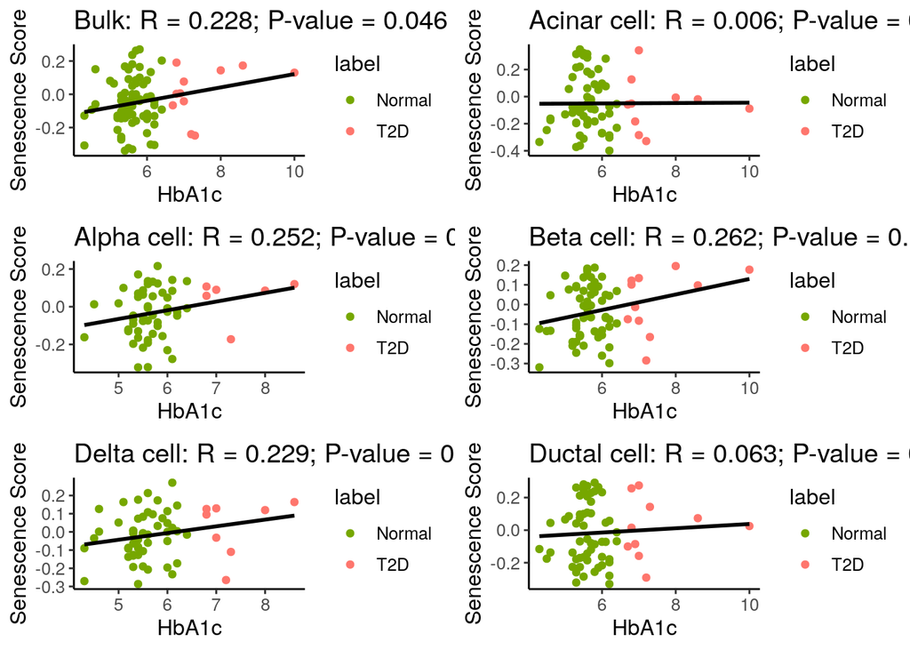

```r
scrna <- log2(as.matrix(pancreas_bulk)+1)
es.dif <- gsva(scrna, list(PS_gene), mx.diff=TRUE, verbose=FALSE, parallel.sz=1)
s = es.dif[1,]
names(s) <- colnames(egm_model1$X_k)

color <- label
color[label==1] <- rgb(254,118,109,maxColorValue = 255)
color[label==0] <- rgb(118,167,0,maxColorValue = 255)
scatter_dat <- data.frame(HbA1c=metadata[sample,]$HbA1c,Sene.Score=s[sample],label=label,color=color)
scatter_dat$label[scatter_dat$label==1] <- "T2D"
scatter_dat$label[scatter_dat$label==0] <- "Normal"
scatter_dat$label <- as.factor(scatter_dat$label)
scatter_dat_filter <- scatter_dat
hba1c_tab <- rbind(hba1c_tab,c(cor(scatter_dat_filter[,1],scatter_dat_filter[,2],method="p"),cor.test(scatter_dat_filter[,1],scatter_dat_filter[,2],method="p")$p.value))
eval(parse(text = paste("p_hba1c_bulk"," <- ggplot(scatter_dat_filter, aes(x=HbA1c, y=Sene.Score, color=label)) + scale_color_manual(values=c(rgb(118,167,0,maxColorValue = 255),rgb(254,118,109,maxColorValue = 255)))+
    geom_point()+theme_classic()+theme(text = element_text(size=12))+geom_smooth(method=lm, se=FALSE, fullrange=TRUE,col='black')",sep="")))
value1 <- round(cor(scatter_dat_filter[,1],scatter_dat_filter[,2],method="p"),3)
value2 <- round(cor.test(scatter_dat_filter[,1],scatter_dat_filter[,2],method="p")$p.value,3)
eval(parse(text = paste("p_hba1c_bulk","<- p_hba1c_bulk","+labs(y='Senescence Score',title='Bulk: R = ",value1, "; P-value = ",value2, "')",sep="")))

plot_grid(p_hba1c_bulk,p_hba1c_1,p_hba1c_2,p_hba1c_3,p_hba1c_4,p_hba1c_5,nrow=3,ncol=2)
```

To further support our discovery, we used the cellular senescence signature downloaded from different database and conducted the same analysis (http://csgene.bioinfo-minzhao.org/)

```r
##cellular senescence genes for human
csgenes = read.table("/mnt/data1/weixu/HiDe/revised/reproduce_pancreas/csgene_human.txt",header=TRUE,sep="\t")

############## Analyze BMI
bmi_tab <- NULL
for(ct in c(1:5)){
PS_gene <- intersect(rownames(tmp_pancreas$cell_type1),c((SASP$Gene),csgenes$GeneSymb));PS_gene <- PS_gene[rowMeans(log2(as.matrix(pancreas_bulk)+1)[PS_gene,])>0.1]
scrna <- egm_model1$X_k[,,ct]
es.dif <- gsva(scrna, list(PS_gene), mx.diff=TRUE, verbose=FALSE, parallel.sz=1)
s = es.dif[1,]
names(s) <- colnames(egm_model1$X_k)

color <- label
color[label==1] <- rgb(254,118,109,maxColorValue = 255)
color[label==0] <- rgb(118,167,0,maxColorValue = 255)
scatter_dat <- data.frame(BMI=metadata[sample,]$BMI,Sene.Score=s[sample],label=label,color=color)
scatter_dat$label[scatter_dat$label==1] <- "T2D"
scatter_dat$label[scatter_dat$label==0] <- "Normal"
scatter_dat$label <- as.factor(scatter_dat$label)
scatter_dat_filter <- scatter_dat[Fra_pancreas$theta[sample,ct]!=0,]
print(cor(scatter_dat_filter[,1],scatter_dat_filter[,2],method="p"))
print(cor.test(scatter_dat_filter[,1],scatter_dat_filter[,2],method="p")$p.value)
bmi_tab <- rbind(bmi_tab,c(cor(scatter_dat_filter[,1],scatter_dat_filter[,2],method="p"),cor.test(scatter_dat_filter[,1],scatter_dat_filter[,2],method="p")$p.value))
eval(parse(text = paste("p_bmi_",ct," <- ggplot(scatter_dat_filter, aes(x=BMI, y=Sene.Score, color=label)) + scale_color_manual(values=c(rgb(118,167,0,maxColorValue = 255),rgb(254,118,109,maxColorValue = 255)))+
    geom_point()+theme_classic()+theme(text = element_text(size=12))+geom_smooth(method=lm, se=FALSE, fullrange=TRUE,col='black')",sep="")))
value1 <- round(cor(scatter_dat_filter[,1],scatter_dat_filter[,2],method="p"),3)
value2 <- round(cor.test(scatter_dat_filter[,1],scatter_dat_filter[,2],method="p")$p.value,3)
eval(parse(text = paste("p_bmi_",ct," <-","p_bmi_",ct,"+labs(y='Senescence Score',title='",pt_ct[ct],": R = ",value1, "; P-value = ",value2, "')",sep="")))
}
```

```
##            [,1]
## [1,] -0.1358192
## [1] 0.2731251
##          [,1]
## [1,] 0.274246
## [1] 0.03897944
##           [,1]
## [1,] 0.2480439
## [1] 0.03841556
##           [,1]
## [1,] 0.1946746
## [1] 0.1430916
##            [,1]
## [1,] 0.04396605
## [1] 0.7259433
```

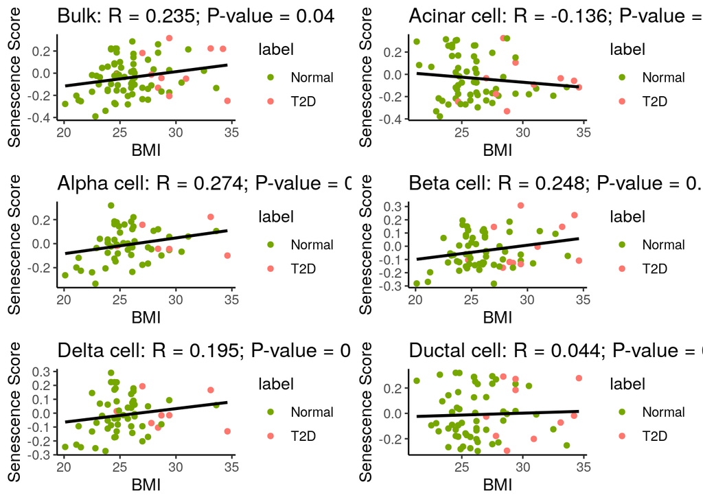

```r
scrna <- log2(as.matrix(pancreas_bulk)+1)
es.dif <- gsva(scrna, list(PS_gene), mx.diff=TRUE, verbose=FALSE, parallel.sz=1)
s = es.dif[1,]
names(s) <- colnames(egm_model1$X_k)

color <- label
color[label==1] <- rgb(254,118,109,maxColorValue = 255)
color[label==0] <- rgb(118,167,0,maxColorValue = 255)
scatter_dat <- data.frame(BMI=metadata[sample,]$BMI,Sene.Score=s[sample],label=label,color=color)
scatter_dat$label[scatter_dat$label==1] <- "T2D"
scatter_dat$label[scatter_dat$label==0] <- "Normal"
scatter_dat$label <- as.factor(scatter_dat$label)
scatter_dat_filter <- scatter_dat
bmi_tab <- rbind(bmi_tab,c(cor(scatter_dat_filter[,1],scatter_dat_filter[,2],method="p"),cor.test(scatter_dat_filter[,1],scatter_dat_filter[,2],method="p")$p.value))
eval(parse(text = paste("p_bmi_bulk"," <- ggplot(scatter_dat_filter, aes(x=BMI, y=Sene.Score, color=label)) + scale_color_manual(values=c(rgb(118,167,0,maxColorValue = 255),rgb(254,118,109,maxColorValue = 255)))+
    geom_point()+theme_classic()+theme(text = element_text(size=12))+geom_smooth(method=lm, se=FALSE, fullrange=TRUE,col='black')",sep="")))
value1 <- round(cor(scatter_dat_filter[,1],scatter_dat_filter[,2],method="p"),3)
value2 <- round(cor.test(scatter_dat_filter[,1],scatter_dat_filter[,2],method="p")$p.value,3)
eval(parse(text = paste("p_bmi_bulk","<- p_bmi_bulk","+labs(y='Senescence Score',title='Bulk: R = ",value1, "; P-value = ",value2, "')",sep="")))

plot_grid(p_bmi_bulk,p_bmi_1,p_bmi_2,p_bmi_3,p_bmi_4,p_bmi_5,nrow=3,ncol=2)
```

Using GSVA to evaluate each sample senescence score, and using the scatter plot to visualize the correlation between senescence of each cell type and HbA1c.

```r
hba1c_tab <- NULL
for(ct in c(1:5)){
PS_gene <- intersect(rownames(tmp_pancreas$cell_type1),c((SASP$Gene),(csgenes$GeneSymb)));PS_gene <- PS_gene[rowMeans(log2(as.matrix(pancreas_bulk)+1)[PS_gene,])>0.1]
scrna <- egm_model1$X_k[,,ct]
es.dif <- gsva(scrna, list(PS_gene), mx.diff=TRUE, verbose=FALSE, parallel.sz=1)
s = es.dif[1,]
names(s) <- colnames(egm_model1$X_k)

color <- label
color[label==1] <- rgb(254,118,109,maxColorValue = 255)
color[label==0] <- rgb(118,167,0,maxColorValue = 255)
scatter_dat <- data.frame(HbA1c=metadata[sample,]$HbA1c,Sene.Score=s[sample],label=label,color=color)
scatter_dat$label[scatter_dat$label==1] <- "T2D"
scatter_dat$label[scatter_dat$label==0] <- "Normal"
scatter_dat$label <- as.factor(scatter_dat$label)
scatter_dat_filter <- scatter_dat[Fra_pancreas$theta[sample,ct]!=0,]
print(cor(scatter_dat_filter[,1],scatter_dat_filter[,2],method="p"))
print(cor.test(scatter_dat_filter[,1],scatter_dat_filter[,2],method="p")$p.value)
hba1c_tab <- rbind(hba1c_tab,c(cor(scatter_dat_filter[,1],scatter_dat_filter[,2],method="p"),cor.test(scatter_dat_filter[,1],scatter_dat_filter[,2],method="p")$p.value))
eval(parse(text = paste("p_hba1c_",ct," <- ggplot(scatter_dat_filter, aes(x=HbA1c, y=Sene.Score, color=label)) + scale_color_manual(values=c(rgb(118,167,0,maxColorValue = 255),rgb(254,118,109,maxColorValue = 255)))+
    geom_point()+theme_classic()+theme(text = element_text(size=12))+geom_smooth(method=lm, se=FALSE, fullrange=TRUE,col='black')",sep="")))
value1 <- round(cor(scatter_dat_filter[,1],scatter_dat_filter[,2],method="p"),3)
value2 <- round(cor.test(scatter_dat_filter[,1],scatter_dat_filter[,2],method="p")$p.value,3)
eval(parse(text = paste("p_hba1c_",ct," <-","p_hba1c_",ct,"+labs(y='Senescence Score',title='",pt_ct[ct],": R = ",value1, "; P-value = ",value2, "')",sep="")))
}
```

```
##             [,1]
## [1,] -0.05077027
## [1] 0.6832625
##           [,1]
## [1,] 0.1778219
## [1] 0.1857164
##           [,1]
## [1,] 0.2192193
## [1] 0.06825131
##           [,1]
## [1,] 0.1323837
## [1] 0.3218685
##             [,1]
## [1,] 0.003324025
## [1] 0.9788676
```

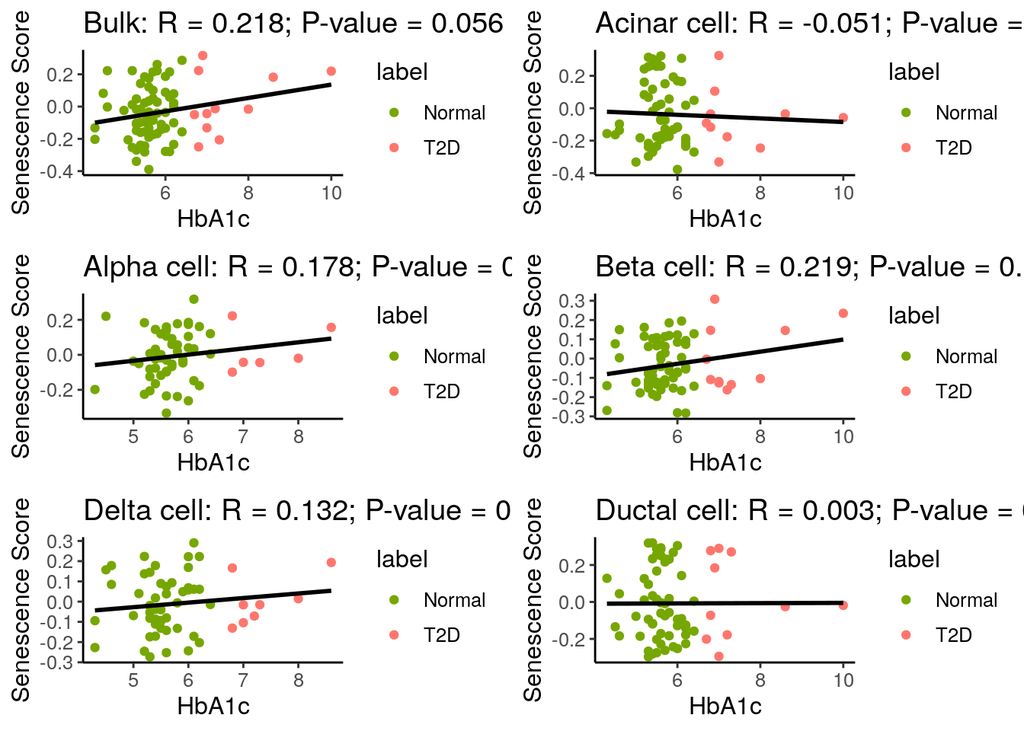

```r
scrna <- log2(as.matrix(pancreas_bulk)+1)
es.dif <- gsva(scrna, list(PS_gene), mx.diff=TRUE, verbose=FALSE, parallel.sz=1)
s = es.dif[1,]
names(s) <- colnames(egm_model1$X_k)

color <- label
color[label==1] <- rgb(254,118,109,maxColorValue = 255)
color[label==0] <- rgb(118,167,0,maxColorValue = 255)
scatter_dat <- data.frame(HbA1c=metadata[sample,]$HbA1c,Sene.Score=s[sample],label=label,color=color)
scatter_dat$label[scatter_dat$label==1] <- "T2D"
scatter_dat$label[scatter_dat$label==0] <- "Normal"
scatter_dat$label <- as.factor(scatter_dat$label)
scatter_dat_filter <- scatter_dat
hba1c_tab <- rbind(hba1c_tab,c(cor(scatter_dat_filter[,1],scatter_dat_filter[,2],method="p"),cor.test(scatter_dat_filter[,1],scatter_dat_filter[,2],method="p")$p.value))
eval(parse(text = paste("p_hba1c_bulk"," <- ggplot(scatter_dat_filter, aes(x=HbA1c, y=Sene.Score, color=label)) + scale_color_manual(values=c(rgb(118,167,0,maxColorValue = 255),rgb(254,118,109,maxColorValue = 255)))+
    geom_point()+theme_classic()+theme(text = element_text(size=12))+geom_smooth(method=lm, se=FALSE, fullrange=TRUE,col='black')",sep="")))
value1 <- round(cor(scatter_dat_filter[,1],scatter_dat_filter[,2],method="p"),3)
value2 <- round(cor.test(scatter_dat_filter[,1],scatter_dat_filter[,2],method="p")$p.value,3)
eval(parse(text = paste("p_hba1c_bulk","<- p_hba1c_bulk","+labs(y='Senescence Score',title='Bulk: R = ",value1, "; P-value = ",value2, "')",sep="")))

plot_grid(p_hba1c_bulk,p_hba1c_1,p_hba1c_2,p_hba1c_3,p_hba1c_4,p_hba1c_5,nrow=3,ncol=2)
```

## Plot the correlation results between beta cell fractions and HbA1c.

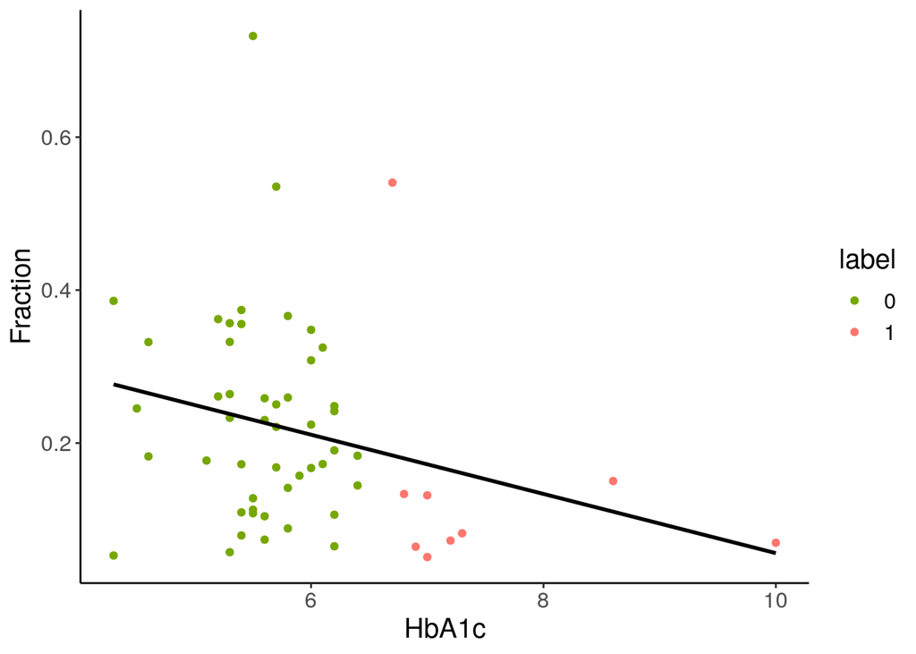

```r
color <- label
color[label==1] <- rgb(254,118,109,maxColorValue = 255)
color[label==0] <- rgb(118,167,0,maxColorValue = 255)
scatter_dat <- data.frame(HbA1c=metadata[sample,]$HbA1c,Fraction=Fra_pancreas$theta[sample,3],label=label,color=color)
scatter_dat$label <- as.factor(scatter_dat$label)

##filter out low abundance cell type fractions
scatter_dat = scatter_dat[scatter_dat$Fraction>0.05,]

p_frac <- ggplot(scatter_dat, aes(x=HbA1c, y=Fraction, color=label)) + scale_color_manual(values=c(rgb(118,167,0,maxColorValue = 255),rgb(254,118,109,maxColorValue = 255)))+
    geom_point()+theme_classic()+theme(text = element_text(size=15))+geom_smooth(method=lm, se=FALSE, fullrange=TRUE,col="black")

p_frac
```

```r
cor.test(scatter_dat$HbA1c,scatter_dat$Fraction)
```

```
##
##  Pearson's product-moment correlation
##
## data:  scatter_dat$HbA1c and scatter_dat$Fraction
## t = -2.0675, df = 55, p-value = 0.0434
## alternative hypothesis: true correlation is not equal to 0
## 95 percent confidence interval:
##  -0.494511339 -0.008579639
## sample estimates:
##        cor
## -0.2685469
```

## Build Weighted Gene Co-expression Network through WGCNA for all cell types.

Concatenating all CSE profile into a large gene expression matrix

```r
pancreas <- cell_type_pancreas <- NULL
for(i in 1:ncol(tmp_pancreas$cell_type1)){
 pancreas <- cbind(pancreas,egm_model1$X_k[,Fra_pancreas$theta[,i]!=0,i])
 cell_type_pancreas <- c(cell_type_pancreas,rep(colnames(tmp_pancreas$cell_type1)[i],sum(Fra_pancreas$theta[,i]!=0)))
}
```

Selecting suitable power value and build topological matrix

```r
powers = c(c(1:10), seq(from = 12, to=30, by=2))
sft = pickSoftThreshold(t(pancreas), powerVector = powers, verbose = 5,networkType="signed")
```

```
## pickSoftThreshold: will use block size 2929.
##  pickSoftThreshold: calculating connectivity for given powers...
##    ..working on genes 1 through 2929 of 15273
```

```
##    ..working on genes 2930 through 5858 of 15273
##    ..working on genes 5859 through 8787 of 15273
##    ..working on genes 8788 through 11716 of 15273
##    ..working on genes 11717 through 14645 of 15273
##    ..working on genes 14646 through 15273 of 15273
##    Power SFT.R.sq  slope truncated.R.sq mean.k. median.k. max.k.
## 1      1    0.843  7.770          0.974    9290    9500.0  11100
## 2      2    0.730  2.550          0.914    6100    6260.0   8530
## 3      3    0.468  1.010          0.666    4260    4300.0   6880
## 4      4    0.134  0.323          0.177    3120    3060.0   5740
## 5      5    0.135 -0.178         -0.062    2380    2240.0   4910
## 6      6    0.598 -0.396          0.484    1880    1680.0   4270
## 7      7    0.737 -0.498          0.662    1520    1280.0   3780
## 8      8    0.776 -0.565          0.712    1260    1000.0   3390
## 9      9    0.791 -0.610          0.736    1060     804.0   3060
## 10    10    0.804 -0.648          0.760     912     649.0   2790
## 11    12    0.797 -0.721          0.773     692     445.0   2360
## 12    14    0.787 -0.788          0.787     543     320.0   2030
## 13    16    0.776 -0.852          0.793     436     237.0   1770
## 14    18    0.772 -0.910          0.805     357     181.0   1560
## 15    20    0.784 -0.954          0.828     297     142.0   1390
## 16    22    0.785 -0.996          0.838     250     112.0   1240
## 17    24    0.794 -1.030          0.851     212      90.1   1120
## 18    26    0.799 -1.070          0.865     182      72.5   1010
## 19    28    0.798 -1.090          0.870     157      58.8    918
## 20    30    0.796 -1.120          0.873     137      47.6    838
```

```r
softPower = 10;
adjacency = adjacency(t(pancreas), power = softPower,type="signed");
TOM = TOMsimilarity(adjacency);
```

```
## ..connectivity..
## ..matrix multiplication (system BLAS)..
## ..normalization..
## ..done.
```

```r
dissTOM = 1-TOM
```

```r
geneTree = hclust(as.dist(dissTOM), method = "average");
sizeGrWindow(12,9)
plot(geneTree, xlab="", sub="", main = "Gene clustering on TOM-based dissimilarity",
labels = FALSE, hang = 0.04);
minModuleSize = 30;
```

Module identification using dynamic tree cut:

```r
dynamicMods = cutreeDynamic(dendro = geneTree, distM = dissTOM,
deepSplit = 2, pamRespectsDendro = FALSE,
minClusterSize = minModuleSize);
```

```
##  ..cutHeight not given, setting it to 0.975  ===>  99% of the (truncated) height range in dendro.
##  ..done.
```

```r
dynamicColors = labels2colors(dynamicMods)
table(dynamicColors)
```

```
## dynamicColors
##         black          blue         brown          cyan     darkgreen
##           704          1971          1840           204            98
##      darkgrey    darkorange       darkred darkturquoise         green
##            81            66           131            92          1210
##   greenyellow        grey60     lightcyan    lightgreen   lightyellow
##           247           162           169           152           150
##       magenta  midnightblue        orange          pink        purple
##           484           191            72           595           467
##           red     royalblue        salmon           tan     turquoise
##          1020           149           232           241          2886
##         white        yellow
##            54          1605
```

```r
sizeGrWindow(8,6)
plotDendroAndColors(geneTree, dynamicColors, "Dynamic Tree Cut",
dendroLabels = FALSE, hang = 0.03,
addGuide = TRUE, guideHang = 0.05,
main = "Gene dendrogram and module colors")
```

Cluster module eigengenes and dissimilarity of module eigengenes to build new tree

```r
MEList = moduleEigengenes(t(pancreas), colors = dynamicColors)
MEs = MEList$eigengenes
# Calculate dissimilarity of module eigengenes
MEDiss = 1-cor(MEs);
# Cluster module eigengenes
METree = hclust(as.dist(MEDiss), method = "average");

MEDissThres = 0.15
# Plot the cut line into the dendrogram
```

Call an automatic merging function and merge module

```r
merge = mergeCloseModules(t(pancreas), dynamicColors, cutHeight = MEDissThres, verbose = 3)
```

```
##  mergeCloseModules: Merging modules whose distance is less than 0.15
##    multiSetMEs: Calculating module MEs.
##      Working on set 1 ...
##      moduleEigengenes: Calculating 27 module eigengenes in given set.
##    multiSetMEs: Calculating module MEs.
##      Working on set 1 ...
##      moduleEigengenes: Calculating 20 module eigengenes in given set.
##    Calculating new MEs...
##    multiSetMEs: Calculating module MEs.
##      Working on set 1 ...
##      moduleEigengenes: Calculating 20 module eigengenes in given set.
```

```r
# The merged module colors
mergedColors = merge$colors;
# Eigengenes of the new merged modules:
mergedMEs = merge$newMEs;
```

```r
sizeGrWindow(12, 9)
plotDendroAndColors(geneTree, cbind(dynamicColors, mergedColors),
c("Dynamic Tree Cut", "Merged dynamic"),
dendroLabels = FALSE, hang = 0.03,
addGuide = TRUE, guideHang = 0.05)
```

Conducting the same analysis in bulk gene expression profile

```r
bulk <- log2(tmp_pancreas$bulk[rownames(pancreas),]+1)

powers = c(c(1:10), seq(from = 12, to=30, by=2))
sft = pickSoftThreshold(t(bulk), powerVector = powers, verbose = 5,networkType="signed")
```

```
## pickSoftThreshold: will use block size 2929.
##  pickSoftThreshold: calculating connectivity for given powers...
##    ..working on genes 1 through 2929 of 15273
##    ..working on genes 2930 through 5858 of 15273
##    ..working on genes 5859 through 8787 of 15273
##    ..working on genes 8788 through 11716 of 15273
##    ..working on genes 11717 through 14645 of 15273
##    ..working on genes 14646 through 15273 of 15273
##    Power SFT.R.sq slope truncated.R.sq mean.k. median.k. max.k.
## 1      1   0.0129  4.73          0.724  7690.0   7660.00   8180
## 2      2   0.2640 -5.29          0.492  4160.0   4110.00   4890
## 3      3   0.5920 -3.86          0.798  2390.0   2340.00   3330
## 4      4   0.6890 -2.77          0.857  1450.0   1400.00   2460
## 5      5   0.7570 -2.25          0.891   929.0    877.00   1930
## 6      6   0.7870 -1.99          0.891   622.0    569.00   1590
## 7      7   0.8160 -1.84          0.897   433.0    380.00   1340
## 8      8   0.8470 -1.73          0.902   313.0    260.00   1160
## 9      9   0.8620 -1.68          0.900   233.0    183.00   1010
## 10    10   0.8830 -1.65          0.905   178.0    131.00    899
## 11    12   0.9080 -1.62          0.909   112.0     70.60    726
## 12    14   0.9310 -1.57          0.924    74.8     40.10    601
## 13    16   0.9370 -1.53          0.924    52.9     24.00    506
## 14    18   0.9540 -1.47          0.943    38.9     14.90    433
## 15    20   0.9590 -1.42          0.948    29.6      9.52    374
## 16    22   0.9710 -1.36          0.962    23.1      6.26    327
## 17    24   0.9720 -1.34          0.965    18.4      4.20    293
## 18    26   0.9610 -1.33          0.952    15.0      2.87    265
## 19    28   0.9610 -1.31          0.953    12.3      1.99    241
## 20    30   0.9640 -1.29          0.959    10.3      1.40    221
```

```r
softPower = 12;
adjacency_bulk = adjacency(t(bulk), power = softPower,type="signed");
TOM_bulk = TOMsimilarity(adjacency_bulk);
```

```
## ..connectivity..
## ..matrix multiplication (system BLAS)..
## ..normalization..
## ..done.
```

```r
dissTOM_bulk = 1-TOM_bulk

geneTree_bulk = hclust(as.dist(dissTOM_bulk), method = "average");
# Plot the resulting clustering tree (dendrogram)
sizeGrWindow(12,9)
plot(geneTree_bulk, xlab="", sub="", main = "Gene clustering on TOM-based dissimilarity",
labels = FALSE, hang = 0.04);
minModuleSize = 30;
# Module identification using dynamic tree cut:
dynamicMods_bulk = cutreeDynamic(dendro = geneTree_bulk, distM = dissTOM_bulk,
deepSplit = 2, pamRespectsDendro = FALSE,
minClusterSize = minModuleSize);
```

```
##  ..cutHeight not given, setting it to 0.994  ===>  99% of the (truncated) height range in dendro.
##  ..done.
```

```r
dynamicColors_bulk = labels2colors(dynamicMods_bulk)
table(dynamicColors_bulk)
```

```
## dynamicColors_bulk
##         bisque4           black            blue           brown          brown4
##              71             425            1054             859              75
##            cyan       darkgreen        darkgrey     darkmagenta  darkolivegreen
##             333             231             208             145             146
##      darkorange     darkorange2         darkred   darkslateblue   darkturquoise
##             187              83             233              68             230
##     floralwhite           green     greenyellow          grey60           ivory
##              88             610             396             277              97
##       lightcyan      lightcyan1      lightgreen lightsteelblue1     lightyellow
##             294             108             277             108             268
##         magenta   mediumpurple3    midnightblue          orange      orangered4
##             413             109             325             188             109
##   paleturquoise            pink           plum1           plum2          purple
##             147             417             112              66             400
##             red       royalblue     saddlebrown          salmon         sienna3
##             508             243             173             335             141
##         skyblue        skyblue3       steelblue             tan        thistle2
##             179             120             165             395              50
##       turquoise          violet           white          yellow     yellowgreen
##            2574             147             183             780             123
```

```r
# Plot the dendrogram and colors underneath
sizeGrWindow(8,6)
plotDendroAndColors(geneTree_bulk, cbind(dynamicColors_bulk),
c("Acinar Expression Module"),
dendroLabels = FALSE, hang = 0.03,
addGuide = TRUE, guideHang = 0.05)


MEList_bulk = moduleEigengenes(t(bulk), colors = dynamicColors_bulk)
MEs_bulk = MEList_bulk$eigengenes
# Calculate dissimilarity of module eigengenes
MEDiss_bulk = 1-cor(MEs_bulk);
# Cluster module eigengenes
METree_bulk = hclust(as.dist(MEDiss_bulk), method = "average");

MEDissThres_bulk = 0.25
# Plot the cut line into the dendrogram
abline(h=MEDissThres_bulk, col = "red")
# Call an automatic merging function
merge_bulk = mergeCloseModules(t(bulk), dynamicColors_bulk, cutHeight = MEDissThres_bulk, verbose = 3)
```

```
##  mergeCloseModules: Merging modules whose distance is less than 0.25
##    multiSetMEs: Calculating module MEs.
##      Working on set 1 ...
##      moduleEigengenes: Calculating 50 module eigengenes in given set.
##    multiSetMEs: Calculating module MEs.
##      Working on set 1 ...
##      moduleEigengenes: Calculating 35 module eigengenes in given set.
##    multiSetMEs: Calculating module MEs.
##      Working on set 1 ...
##      moduleEigengenes: Calculating 32 module eigengenes in given set.
##    multiSetMEs: Calculating module MEs.
##      Working on set 1 ...
##      moduleEigengenes: Calculating 31 module eigengenes in given set.
##    Calculating new MEs...
##    multiSetMEs: Calculating module MEs.
##      Working on set 1 ...
##      moduleEigengenes: Calculating 31 module eigengenes in given set.
```

```r
# The merged module colors
mergedColors_bulk = merge_bulk$colors;
# Eigengenes of the new merged modules:
mergedMEs_bulk = merge_bulk$newMEs;
```

Plot cell type-specific co-expression modules and bulk gene expression modules together

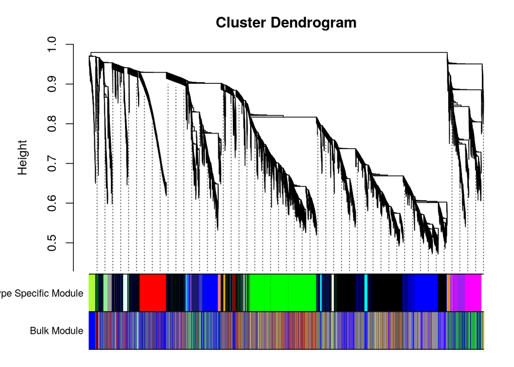

```r
plotDendroAndColors(geneTree, cbind(mergedColors,mergedColors_bulk),
c("Cell Type Specific Module", "Bulk Module"),
dendroLabels = FALSE, hang = 0.03,
addGuide = TRUE, guideHang = 0.05)
```

## Identify cell type specific modules

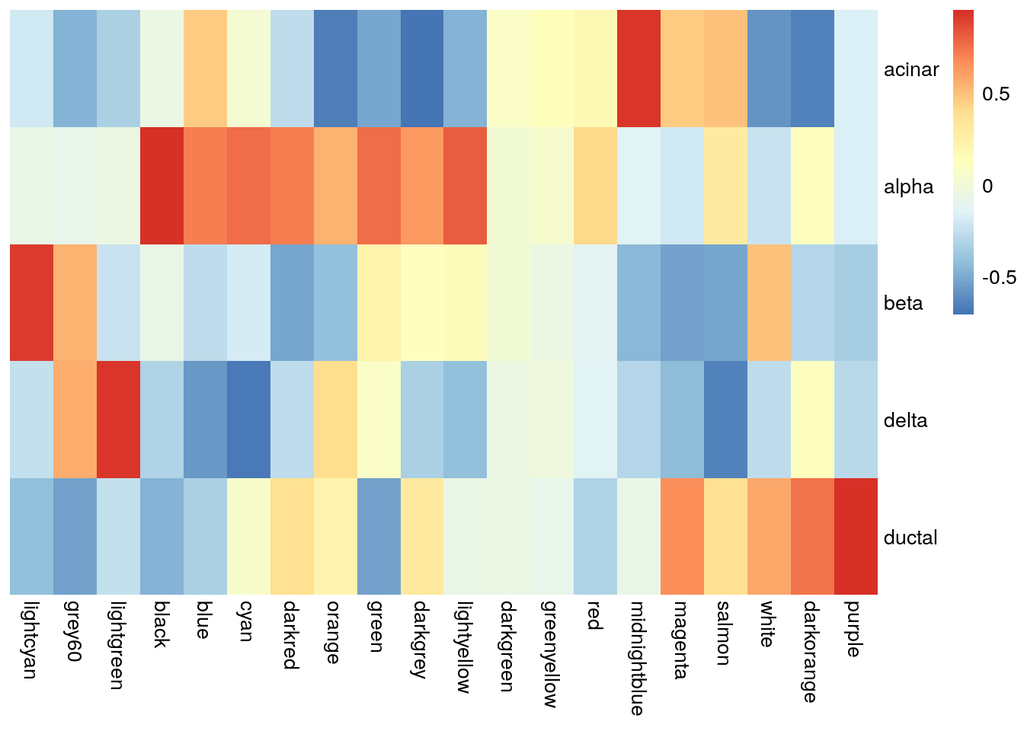

```r
##visualize each module functions
ct_matrix = matrix(0,nrow= nrow(Fra_pancreas$theta)*ncol(Fra_pancreas$theta),ncol=ncol(Fra_pancreas$theta))
for(i in 1:ncol(ct_matrix) )ct_matrix[((i-1)*nrow(Fra_pancreas$theta)+1):(i*nrow(Fra_pancreas$theta)),i] = Fra_pancreas$theta[,i]
colnames(ct_matrix) <- colnames(Fra_pancreas$theta)
colnames(mergedMEs) <- gsub("ME","",colnames(mergedMEs))
ct_matrix = ct_matrix[rowSums(ct_matrix)>0,]
ct_matrix[ct_matrix!=0] = 1
pheatmap(t(cor(mergedMEs,ct_matrix,method="p")),cluster_cols=FALSE,cluster_row=FALSE,border=FALSE)
```

## Conducting Go enrichment analysis for cell type-specific modules

```r
lightcyan_gene <- rownames(pancreas)[mergedColors=="lightcyan"]
lightcyan_gene <- bitr(lightcyan_gene,fromType="SYMBOL",toType="ENTREZID",org.Hs.eg.db)
goterm_lightcyan <- as.data.frame(enrichGO(lightcyan_gene[,2], ont="BP",pvalueCutoff = 0.05,qvalueCutoff = 0.05,OrgDb = org.Hs.eg.db,readable=TRUE))

lightgreen_gene <- rownames(pancreas)[mergedColors=="lightgreen"]
lightgreen_gene <- bitr(lightgreen_gene,fromType="SYMBOL",toType="ENTREZID",org.Hs.eg.db)
goterm_lightgreen <- as.data.frame(enrichGO(lightgreen_gene[,2], ont="BP",pvalueCutoff = 0.05,qvalueCutoff = 0.05,OrgDb = org.Hs.eg.db,readable=TRUE))

midnightblue_gene <- rownames(pancreas)[mergedColors=="midnightblue"]
midnightblue_gene <- bitr(midnightblue_gene,fromType="SYMBOL",toType="ENTREZID",org.Hs.eg.db)
goterm_midnightblue <- as.data.frame(enrichGO(midnightblue_gene[,2], ont="BP",pvalueCutoff = 0.05,qvalueCutoff = 0.05,OrgDb = org.Hs.eg.db,readable=TRUE))

purple_gene <- rownames(pancreas)[mergedColors=="purple"]
purple_gene <- bitr(purple_gene,fromType="SYMBOL",toType="ENTREZID",org.Hs.eg.db)
goterm_purple <- as.data.frame(enrichGO(purple_gene[,2], ont="BP",pvalueCutoff = 0.05,qvalueCutoff = 0.05,OrgDb = org.Hs.eg.db,readable=TRUE))

black_gene <- rownames(pancreas)[mergedColors=="black"]
black_gene <- bitr(black_gene,fromType="SYMBOL",toType="ENTREZID",org.Hs.eg.db)
```

```r
goterm_black <- as.data.frame(enrichGO(black_gene[,2], ont="BP",pvalueCutoff = 0.05,qvalueCutoff = 0.05,OrgDb = org.Hs.eg.db,readable=TRUE))


df_barMarker2 <- data.frame(pval = -log10((goterm_purple)[1:5,]$p.adjust),goterm=(goterm_purple)[1:5,]$Description)
df_barMarker2$goterm_name <- factor(c((goterm_purple)[1:5,]$Description),levels=c(c((goterm_purple)[1:5,]$Description)[order(-log10((goterm_purple)[1:5,]$p.adjust),decreasing=FALSE)]))
p_purple_go <-ggplot(data=df_barMarker2, aes(x=goterm_name, y=pval)) +
    geom_bar(stat="identity",fill="purple")+coord_flip()+theme_classic()+theme(text = element_text(size=15))

df_barMarker2 <- data.frame(pval = -log10((goterm_lightgreen)[1:5,]$p.adjust),goterm=(goterm_lightgreen)[1:5,]$Description)
df_barMarker2$goterm_name <- factor(c((goterm_lightgreen)[1:5,]$Description),levels=c(c((goterm_lightgreen)[1:5,]$Description)[order(-log10((goterm_lightgreen)[1:5,]$p.adjust),decreasing=FALSE)]))
p_lightgreen_go <-ggplot(data=df_barMarker2, aes(x=goterm_name, y=pval)) +
    geom_bar(stat="identity",fill="lightgreen")+coord_flip()+theme_classic()+theme(text = element_text(size=15))

df_barMarker2 <- data.frame(pval = -log10((goterm_lightcyan)[1:5,]$p.adjust),goterm=(goterm_lightcyan)[1:5,]$Description)
df_barMarker2$goterm_name <- factor(c((goterm_lightcyan)[1:5,]$Description),levels=c(c((goterm_lightcyan)[1:5,]$Description)[order(-log10((goterm_lightcyan)[1:5,]$p.adjust),decreasing=FALSE)]))
p_lightcyan_go <-ggplot(data=df_barMarker2, aes(x=goterm_name, y=pval)) +
    geom_bar(stat="identity",fill="lightcyan")+coord_flip()+theme_classic()+theme(text = element_text(size=15))

df_barMarker2 <- data.frame(pval = -log10((goterm_black)[1:5,]$p.adjust),goterm=(goterm_black)[1:5,]$Description)
df_barMarker2$goterm_name <- factor(c((goterm_black)[1:5,]$Description),levels=c(c((goterm_black)[1:5,]$Description)[order(-log10((goterm_black)[1:5,]$p.adjust),decreasing=FALSE)]))
p_black_go <-ggplot(data=df_barMarker2, aes(x=goterm_name, y=pval)) +
    geom_bar(stat="identity",fill="black")+coord_flip()+theme_classic()+theme(text = element_text(size=15))

df_barMarker2 <- data.frame(pval = -log10((goterm_midnightblue)[1:5,]$p.adjust),goterm=(goterm_midnightblue)[1:5,]$Description)
df_barMarker2$goterm_name <- factor(c((goterm_midnightblue)[1:5,]$Description),levels=c(c((goterm_midnightblue)[1:5,]$Description)[order(-log10((goterm_midnightblue)[1:5,]$p.adjust),decreasing=FALSE)]))
p_midnightblue_go <-ggplot(data=df_barMarker2, aes(x=goterm_name, y=pval)) +
    geom_bar(stat="identity",fill="midnightblue")+coord_flip()+theme_classic()+theme(text = element_text(size=15))
```

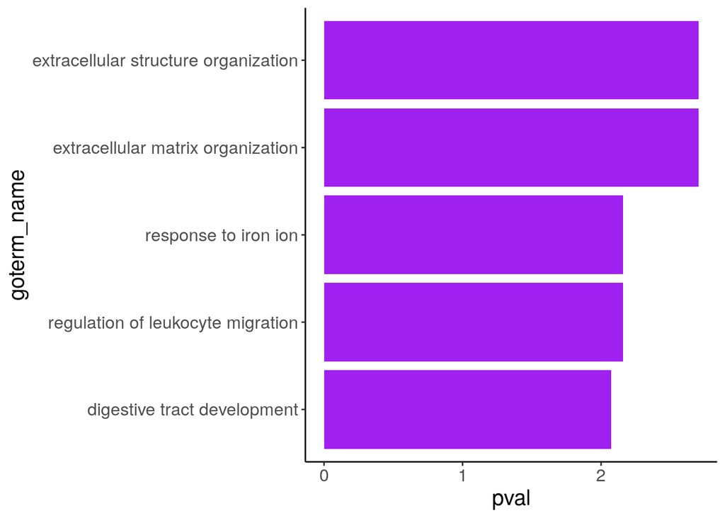

```r
p_purple_go
```

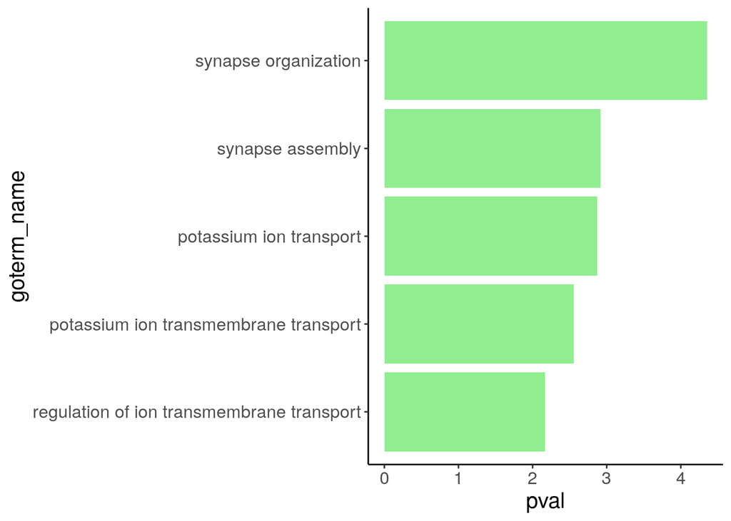

```r
p_lightgreen_go
```

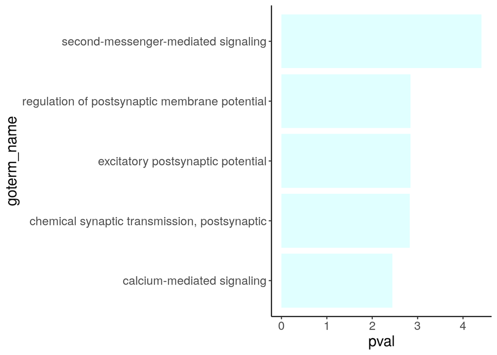

```r
p_lightcyan_go
```

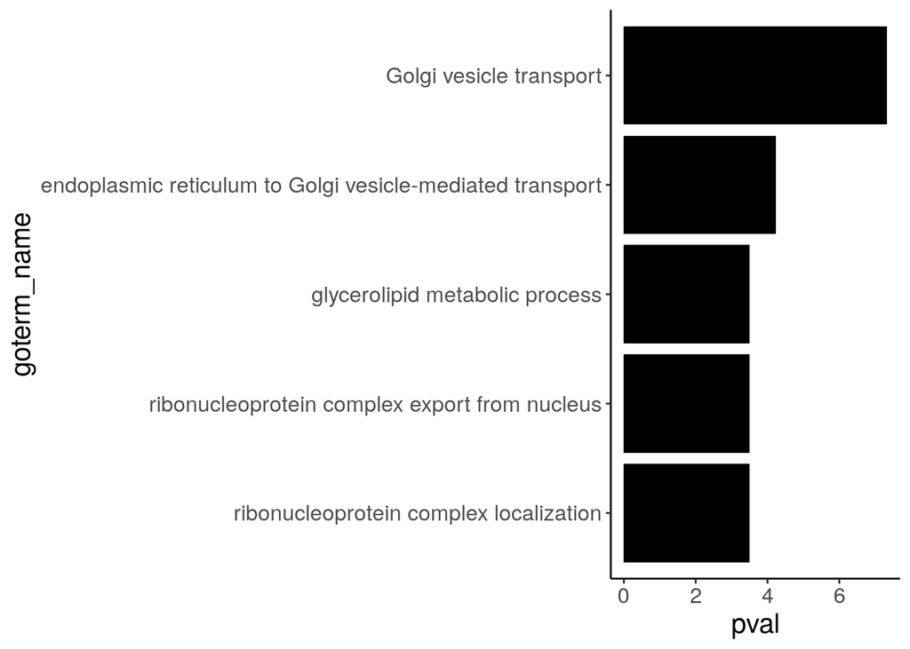

```r
p_black_go
```

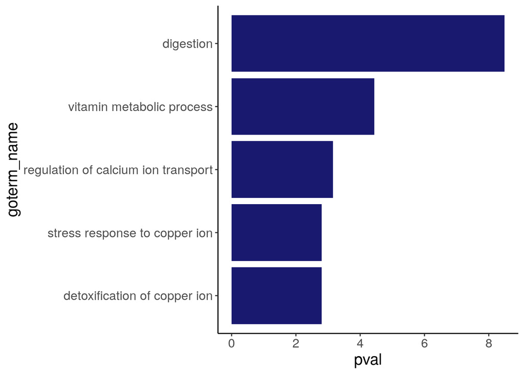

```r
p_midnightblue_go
```

## Visualize cell type specific module in heatmap through scater

```r
names(mergedColors) = rownames(pancreas)
pancreas_sub <- pancreas[mergedColors %in% c("lightgreen","purple","lightcyan","black","midnightblue"),]
mergedColors_sub <- mergedColors[mergedColors %in% c("lightgreen","purple","lightcyan","black","midnightblue")]
colnames(pancreas_sub) <- paste0("Sample-",1:ncol(pancreas_sub),sep="")

pancreas_sub_new <- mergedColors_sub_new <- NULL
for(i in c("midnightblue","black","lightcyan","lightgreen","purple")){
 pancreas_sub_new <- rbind(pancreas_sub_new, pancreas_sub[mergedColors_sub %in% i,])
 mergedColors_sub_new <- c(mergedColors_sub_new, mergedColors_sub[mergedColors_sub %in% i])
}
pancreas_sub <- pancreas_sub_new
mergedColors_sub <- mergedColors_sub_new
rm(pancreas_sub_new,mergedColors_sub_new)
gc()
```

```
##              used    (Mb) gc trigger    (Mb)   max used    (Mb)
## Ncells    8477225   452.8   26202424  1399.4   26202424  1399.4
## Vcells 1615130230 12322.5 2575506856 19649.6 2459795723 18766.8
```

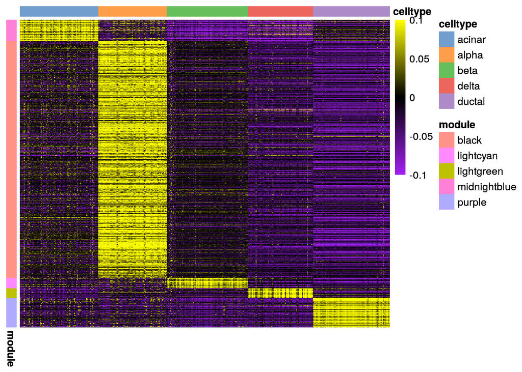

```r
pancreas_sub <- pancreas_sub[apply(pancreas_sub,1,var)>1e-4,]
sce_pancreas <- SingleCellExperiment(assays = list(logcounts = pancreas_sub))
sce_pancreas$celltype <- cell_type_pancreas
annotation_row= data.frame(module=mergedColors_sub[rownames(pancreas_sub)])
ann_colors <- list(module = c(midnightblue="midnightblue",
                              black ="black",
                              lightcyan="lightcyan",
                              lightgreen="lightgreen",
                              purple="purple"))
p <- scater::plotHeatmap(sce_pancreas, features = rownames(pancreas_sub),
                    center = TRUE, zlim = c(-0.1, 0.1), colour_columns_by = "celltype", show_colnames = FALSE,show_rownames = FALSE,
                    cluster_cols = FALSE,annotation_row=annotation_row,cluster_row=FALSE,fontsize_row = 6, color = colorRampPalette(c("purple", "black",
                                                                                   "yellow"))(90))
p
```